# TASK6：基于机器学习模型的量化交易策略

> 从因子到策略：A 股基本面因子 ML 建模与回测完整流程

**姓名：李明凯**

## 第一部分：环境准备与数据加载

```python
# 1.1 导入库
import pandas as pd
import numpy as np
import matplotlib.pyplot as plt
import matplotlib.gridspec as gridspec
from matplotlib.font_manager import FontProperties
from matplotlib.ticker import FuncFormatter
import warnings
warnings.filterwarnings('ignore')

# 中文字体配置
chinese_font = FontProperties(fname=r'C:\Windows\Fonts\msyh.ttc', size=12)
chinese_font_title = FontProperties(fname=r'C:\Windows\Fonts\msyh.ttc', size=14)
chinese_font_small = FontProperties(fname=r'C:\Windows\Fonts\msyh.ttc', size=10)

# sklearn 库
from sklearn.preprocessing import StandardScaler
from sklearn.tree import DecisionTreeClassifier
from sklearn.ensemble import RandomForestClassifier, GradientBoostingClassifier
from sklearn.linear_model import LogisticRegression
from sklearn.metrics import (accuracy_score, precision_score, recall_score,
                             f1_score, roc_auc_score, confusion_matrix,
                             roc_curve)

# 设置 matplotlib 全局样式
plt.style.use('default')
plt.rcParams['axes.grid'] = True
plt.rcParams['grid.alpha'] = 0.3
plt.rcParams['figure.dpi'] = 120

print("✅ 所有库导入成功")
print(f"  pandas: {pd.__version__}")
print(f"  numpy: {np.__version__}")
print(f"  sklearn: {__import__('sklearn').__version__}")
```

```
✅ 所有库导入成功
  pandas: 3.0.3
  numpy: 2.5.1
  sklearn: 1.9.0
```

```python
# 1.2 加载数据
df = pd.read_csv('model_data.csv')

# 解析日期
df['Date'] = pd.to_datetime(df['Date'])
df = df.sort_values(['Date', 'Code']).reset_index(drop=True)

print(f"数据集形状: {df.shape}")
print(f"时间范围: {df['Date'].min().date()} ~ {df['Date'].max().date()}")
print(f"季度数量: {df['Date'].nunique()}")
print(f"股票数量: {df['Code'].nunique()}")
print(f"字段数量: {len(df.columns)}")
print()
print("前5行预览:")
display(df.head())
```

```
数据集形状: (39616, 22)
时间范围: 2020-03-31 ~ 2022-06-30
季度数量: 10
股票数量: 4281
字段数量: 22

前5行预览:
```

|  | Date | Code | 企业倍数(EV除EBITDA) | 市净率PB(MRQ) | 市现率PCF(现金净流量TTM) | 市现率PCF(经营现金流TTM) | 市盈率PE(TTM) | 市盈率PE(TTM,扣除非经常性损益) | 市销率PS(TTM) | 股息率(近12个月) | ... | 净资产同比增长率 | 利润总额(同比增长率) | 基本每股收益(同比增长率) | 总资产同比增长率 | 现金净流量同比增长率 | 经营活动产生的现金流量净额(同比增长率) | 营业利润(同比增长率) | 营业总收入(同比增长率) | 营业收入(同比增长率) | Next_Ret |
| --- | --- | --- | --- | --- | --- | --- | --- | --- | --- | --- | --- | --- | --- | --- | --- | --- | --- | --- | --- | --- | --- |
| 0 | 2020-03-31 | 1 | 178.031265 | 0.909758 | 14.393912 | -6.206015 | 8.809922 | 8.844113 | 1.800517 | 1.002316 | ... | 40.415162 | 13.3078 | 5.263158 | 17.056297 | -103.110158 | -66.1759 | 13.7685 | 16.7816 | 16.7816 | 0.0170 |
| 1 | 2020-03-31 | 2 | 4.562003 | 1.541541 | -18.198923 | 6.345376 | 7.457793 | 7.566347 | 0.787999 | 4.074472 | ... | 19.747471 | -18.3255 | 8.823529 | 12.160419 | 116.682386 | 88.9421 | -18.0492 | -1.2409 | -1.2409 | 0.0191 |
| 2 | 2020-03-31 | 4 | 578.868794 | 50.715286 | -52.217579 | -82.899211 | -182.321625 | -126.599551 | 23.008403 | 0.680641 | ... | 1118.297690 | -71.9394 | -63.736264 | 815.727417 | -331.488088 | -1056.7178 | -73.7875 | -78.2586 | -78.2586 | -0.0220 |
| 3 | 2020-03-31 | 5 | 12.916891 | 1.887379 | 275.669556 | 43.351010 | 15.524466 | -16.339995 | 4.311851 | 0.987982 | ... | 4.257791 | -27.2351 | -17.857143 | -5.537448 | -110.954222 | -64.5941 | -34.3807 | -45.4093 | -45.4093 | -0.0401 |
| 4 | 2020-03-31 | 6 | 6.304441 | 0.947030 | 3.682145 | 4.324183 | 7.499029 | 7.368639 | 1.622587 | 4.352679 | ... | 8.797335 | 36.3633 | 15.468940 | 9.346712 | -132.572276 | -48.0219 | 44.6186 | 57.7314 | 57.7314 | 0.5600 |

5 rows × 22 columns

```python
# 1.3 数据诊断

# 1.3.1 缺失值检查
print("=" * 60)
print("【缺失值检查】")
missing = df.isnull().sum()
if missing.sum() == 0:
    print("✅ 数据无缺失值！")
else:
    print(missing[missing > 0])

# 1.3.2 每季度股票数量
print("\n" + "=" * 60)
print("【每季度股票数量】")
quarterly_counts = df.groupby('Date').size()
print(quarterly_counts.to_string())

# 1.3.3 Next_Ret 分布
print("\n" + "=" * 60)
print("【Next_Ret（下期收益率）分布】")
print(df['Next_Ret'].describe())

print(f"\n正收益占比: {(df['Next_Ret'] > 0).mean():.2%}")
print(f"负收益占比: {(df['Next_Ret'] <= 0).mean():.2%}")

# 1.3.4 极端值检查
p1 = df['Next_Ret'].quantile(0.01)
p99 = df['Next_Ret'].quantile(0.99)
print(f"\n1% 分位数: {p1:.4f}")
print(f"99% 分位数: {p99:.4f}")

# 1.3.5 因子概览
factor_cols = [c for c in df.columns if c not in ['Date', 'Code', 'Next_Ret']]
print(f"\n因子数量: {len(factor_cols)}")
print(f"因子列表: {factor_cols}")

# 1.3.6 日期顺序
dates_sorted = sorted(df['Date'].unique())
print(f"\n所有日期（按时间排序）:")
for i, d in enumerate(dates_sorted, 1):
    print(f"  Q{i}: {d.date()}")
```

```
============================================================
【缺失值检查】
✅ 数据无缺失值！

============================================================
【每季度股票数量】
Date
2020-03-31    3627
2020-06-30    3667
2020-09-30    3781
2020-12-31    3853
2021-03-31    3916
2021-06-30    4011
2021-09-30    4098
2021-12-31    4173
2022-03-31    4228
2022-06-30    4262

============================================================
【Next_Ret（下期收益率）分布】
count    39616.000000
mean         0.027025
std          0.251363
min         -0.799900
25%         -0.116200
50%         -0.013800
75%          0.111600
max          6.406600
Name: Next_Ret, dtype: float64

正收益占比: 46.39%
负收益占比: 53.61%

1% 分位数: -0.3638
99% 分位数: 0.9157

因子数量: 19
因子列表: ['企业倍数(EV除EBITDA)', '市净率PB(MRQ)', '市现率PCF(现金净流量TTM)', '市现率PCF(经营现金流TTM)', '市盈率PE(TTM)', '市盈率PE(TTM,扣除非经常性损益)', '市销率PS(TTM)', '股息率(近12个月)', 'MV', '净利润同比增长率', '净资产同比增长率', '利润总额(同比增长率)', '基本每股收益(同比增长率)', '总资产同比增长率', '现金净流量同比增长率', '经营活动产生的现金流量净额(同比增长率)', '营业利润(同比增长率)', '营业总收入(同比增长率)', '营业收入(同比增长率)…

所有日期（按时间排序）:
  Q1: 2020-03-31
  Q2: 2020-06-30
  Q3: 2020-09-30
  Q4: 2020-12-31
  Q5: 2021-03-31
  Q6: 2021-06-30
  Q7: 2021-09-30
  Q8: 2021-12-31
  Q9: 2022-03-31
  Q10: 2022-06-30
```

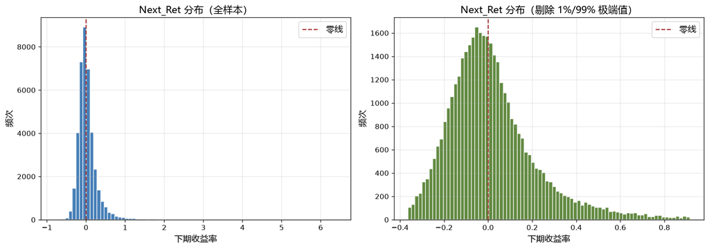

```
正样本占比: 46.39% — 类别基本均衡
```

```python
# 1.4 可视化：Next_Ret 分布直方图
fig, axes = plt.subplots(1, 2, figsize=(14, 5))

# 全样本分布
axes[0].hist(df['Next_Ret'], bins=80, color='#185FA5', edgecolor='white', alpha=0.8)
axes[0].axvline(0, color='#A32D2D', linestyle='--', linewidth=1.5, label='零线')
axes[0].set_title('Next_Ret 分布（全样本）', fontproperties=chinese_font_title)
axes[0].set_xlabel('下期收益率', fontproperties=chinese_font)
axes[0].set_ylabel('频次', fontproperties=chinese_font)
axes[0].legend(prop=chinese_font)

# 缩尾后分布（剔除极端值）
clean = df[(df['Next_Ret'] > df['Next_Ret'].quantile(0.01)) &
           (df['Next_Ret'] < df['Next_Ret'].quantile(0.99))]
axes[1].hist(clean['Next_Ret'], bins=80, color='#3B6D11', edgecolor='white', alpha=0.8)
axes[1].axvline(0, color='#A32D2D', linestyle='--', linewidth=1.5, label='零线')
axes[1].set_title('Next_Ret 分布（剔除 1%/99% 极端值）', fontproperties=chinese_font_title)
axes[1].set_xlabel('下期收益率', fontproperties=chinese_font)
axes[1].set_ylabel('频次', fontproperties=chinese_font)
axes[1].legend(prop=chinese_font)

plt.tight_layout()
plt.savefig('next_ret_distribution.png', dpi=150, bbox_inches='tight')
plt.show()
print(f"\n正样本占比: {(df['Next_Ret'] > 0).mean():.2%} — 类别基本均衡")
```

## 第二部分：基于机器学习模型的交易策略理论（第 1 问）

### 2.1 核心理念

**基于 ML 的交易策略**区别于传统量化策略的核心在于：

1. **数据驱动而非规则驱动**  
   传统策略（如 TASK3 的双均线）依赖人为设定的规则；ML 策略让算法从历史数据中**自动学习**因子与未来收益之间的映射关系。
2. **预测驱动决策**  
   ML 模型输出对资产未来走势的预测（分类 → 涨/跌；回归 → 收益幅度），然后将预测信号映射为交易指令（持仓/空仓/仓位比例）。
3. **因子组合优化**  
   ML 天然适合处理高维因子空间，能自动捕捉因子间的交互效应和非线性关系。例如：**低估值 × 高增长**的组合效果远好于单独使用任一因子。

> 核心公式：传统策略 `signal = f(factor1, factor2, ...)` 由人手工设计；  
> ML 策略 `signal = ŷ = M(X)` 由模型从数据中学习。

### 2.2 优点

| 优点 | 说明 |
| --- | --- |
| **自动化模式发现** | 自动挖掘人类难以察觉的复杂非线性关系 |
| **高维因子处理** | 同时处理几十到上百个因子，树模型/正则化不怕维度灾难 |
| **动态适应** | 滚动训练/在线学习可使模型适应市场风格切换 |
| **减少主观偏差** | 数据驱动替代经验直觉，避免情绪化决策 |
| **可扩展性强** | 同一套框架可迁移到不同资产、市场、时间周期 |

### 2.3 缺点

| 缺点 | 说明 |
| --- | --- |
| **过拟合风险极高 ⚠️** | 金融数据信噪比极低（< 0.05），模型极易"学习"噪声 |
| **数据泄漏** | 特征构造或划分不当会引入未来信息，导致"虚假繁荣" |
| **非平稳性** | 市场统计特性随时间改变，历史模式可能失效（概念漂移） |
| **交易成本侵蚀** | ML 模型往往换手率高，收益被摩擦成本大幅吃掉 |
| **可解释性差** | 复杂模型（RF/GBM）决策过程不透明，难以风控归因 |
| **小样本困境** | 金融数据通常只有数十年，远低于 CV/NLP 的量级 |

### 2.4 金融 ML vs 标准 ML 的关键差异

| 维度 | 标准 ML | 金融 ML |
| --- | --- | --- |
| 信噪比 | 较高（CV: ~0.5+） | **极低**（< 0.05） |
| 数据独立性 | 样本独立同分布 | **时序自相关** |
| 数据划分 | 随机打乱 | **必须按时间序** |
| 非平稳性 | 通常忽略 | **关键挑战** |
| 评估指标 | Accuracy / AUC | 还需**回测指标**（夏普/最大回撤） |

## 第三部分：量化模型中常见自变量（因子）与应变量（第 2 问）

### 3.1 常见自变量（特征 / Factors）

量化 ML 模型的自变量按数据来源分为以下几大类：

#### （一）基本面因子（本任务主力）

反映公司财务状况、估值水平与成长性，是 A 股量化选股最常用的因子族。

| 因子 | 含义 | 逻辑方向 |
| --- | --- | --- |
| PE(TTM) | 滚动市盈率 | 估值越低→潜在收益越高 |
| PB(MRQ) | 市净率 | 同上 |
| 股息率 | 近12个月股息/股价 | 高股息→安全边际高 |
| MV（市值） | 公司总市值 | 小市值效应（A股显著） |
| 净利润同比增长率 | 盈利增速 | 高增长→股价驱动 |
| 营业收入同比增长率 | 收入增速 | 同上 |
| EV/EBITDA | 企业价值倍数 | 综合估值指标 |

#### （二）技术面因子（可扩展）

| 因子 | 含义 |
| --- | --- |
| 动量因子 | N 日收益率、均线偏离度 |
| 波动因子 | N 日波动率、ATR |
| 量价因子 | 成交量变化率、量价背离 |
| 技术指标 | RSI、MACD、布林带 |

#### （三）宏观因子（可扩展）

利率、M2 增速、CPI、PMI、社融数据等。

### 3.2 常见应变量（标签 / Target）

| 类型 | 定义 | 适用场景 |
| --- | --- | --- |
| **二分类 ✅（本任务选用）** | `y = 1` 若 `Next_Ret > 0`，否则 `0` | 方向性择时 |
| **回归** | `y = Next_Ret` 连续值 | 收益幅度预测（更精细但更难） |
| **排序（Rank IC）** | 截面排序收益 | 多空组合、选股 |
| **多分类** | 按分位数将 `Next_Ret` 分箱 | 多档位决策 |

## 第四部分：因子工程（第 3 问 — 第 2 步）

```python
# 4.1 基础因子列名
factor_cols = [c for c in df.columns if c not in ['Date', 'Code', 'Next_Ret']]
print(f"原始因子数: {len(factor_cols)}")
print("原始因子:", factor_cols)

# 复制一份用于特征工程
data = df.copy()
```

```
原始因子数: 19
原始因子: ['企业倍数(EV除EBITDA)', '市净率PB(MRQ)', '市现率PCF(现金净流量TTM)', '市现率PCF(经营现金流TTM)', '市盈率PE(TTM)', '市盈率PE(TTM,扣除非经常性损益)', '市销率PS(TTM)', '股息率(近12个月)', 'MV', '净利润同比增长率', '净资产同比增长率', '利润总额(同比增长率)', '基本每股收益(同比增长率)', '总资产同比增长率', '现金净流量同比增长率', '经营活动产生的现金流量净额(同比增长率)', '营业利润(同比增长率)', '营业总收入(同比增长率)', '营业收入(同比增长率)…
```

```python
# 4.2 派生新特征

# (1) 估值派生：Earning Yield（收益率的倒数，更接近正态分布）
data['EarningYield_PE'] = 1 / data['市盈率PE(TTM)'].clip(lower=0.01)  # 防除零
data['EarningYield_PE_扣非'] = 1 / data['市盈率PE(TTM,扣除非经常性损益)'].clip(lower=0.01)

# (2) 规模因子：市值对数化（消除偏态）
data['LogMV'] = np.log(data['MV'].clip(lower=1))

# (3) 成长质量：净利润增速 - 营收增速（差距大说明盈利质量存疑）
data['Profit_Revenue_Gap'] = data['净利润同比增长率'] - data['营业收入(同比增长率)']

# (4) PEG 指标：PE / 净利润增速（估值与成长的匹配度，越低越好）
# 处理负增速：取绝对值加符号标记
eps_growth = data['基本每股收益(同比增长率)']
peg_raw = data['市盈率PE(TTM)'] / eps_growth.abs().clip(lower=0.1)
data['PEG'] = peg_raw * np.sign(eps_growth)  # 负增速时 PEG 为负

# (5) 现金流质量：经营现金流增速 / 净利润增速
net_profit_growth = data['净利润同比增长率'].clip(lower=0.01)
data['Cashflow_Quality'] = data['经营活动产生的现金流量净额(同比增长率)'] / net_profit_growth

# (6) 综合杠杆：总资产增速 - 净资产增速（负债扩张程度）
data['Leverage_Expansion'] = data['总资产同比增长率'] - data['净资产同比增长率']

# (7) 股息率调整：股息率 × LogMV（大公司高股息）
data['Div_Yield_Adj'] = data['股息率(近12个月)'] * data['LogMV']

# (8) EV/EBITDA 的倒数（类似 Earning Yield）
data['EarningYield_EV'] = 1 / data['企业倍数(EV除EBITDA)'].clip(lower=0.01)

print("✅ 特征派生完成")

# 列出所有派生特征
derived_cols = [c for c in data.columns if c not in df.columns]
print(f"\n新增派生特征 ({len(derived_cols)} 个):")
for c in derived_cols:
    print(f"  - {c}")

# 构建完整特征集
all_features = factor_cols + derived_cols
print(f"\n总特征数: {len(all_features)}")
```

```
✅ 特征派生完成

新增派生特征 (9 个):
  - EarningYield_PE
  - EarningYield_PE_扣非
  - LogMV
  - Profit_Revenue_Gap
  - PEG
  - Cashflow_Quality
  - Leverage_Expansion
  - Div_Yield_Adj
  - EarningYield_EV

总特征数: 28
```

```python
# 4.3 缺失值与极端值处理

print("【缺失值检查】")
nan_counts = data[all_features].isnull().sum()
if nan_counts.sum() > 0:
    print(f"存在 {nan_counts.sum()} 个缺失值，进行中位数填充...")
    for col in all_features:
        if data[col].isnull().any():
            data[col] = data[col].fillna(data[col].median())
            print(f"  - {col}: {nan_counts[col]} 个缺失 → 中位数填充")
else:
    print("✅ 无缺失值")

# 极端值处理：MAD 法（中位数绝对偏差）缩尾
print("\n【极端值处理】")
for col in all_features:
    med = data[col].median()
    mad = (data[col] - med).abs().median() * 1.4826  # MAD = 1.4826 * median(|x - median|)
    lower = med - 5 * mad
    upper = med + 5 * mad
    n_clipped = ((data[col] < lower) | (data[col] > upper)).sum()
    data[col] = data[col].clip(lower, upper)
    if n_clipped > 0:
        print(f"  - {col}: 缩尾 {n_clipped} 个极端值 (上下 5×MAD)")

print("\n✅ 数据处理完成")
```

```
【缺失值检查】
✅ 无缺失值

【极端值处理】
  - 企业倍数(EV除EBITDA): 缩尾 3347 个极端值 (上下 5×MAD)
  - 市净率PB(MRQ): 缩尾 2080 个极端值 (上下 5×MAD)
  - 市现率PCF(现金净流量TTM): 缩尾 4033 个极端值 (上下 5×MAD)
  - 市现率PCF(经营现金流TTM): 缩尾 4554 个极端值 (上下 5×MAD)
  - 市盈率PE(TTM): 缩尾 3380 个极端值 (上下 5×MAD)
  - 市盈率PE(TTM,扣除非经常性损益): 缩尾 3705 个极端值 (上下 5×MAD)
  - 市销率PS(TTM): 缩尾 2127 个极端值 (上下 5×MAD)
  - 股息率(近12个月): 缩尾 1627 个极端值 (上下 5×MAD)
  - MV: 缩尾 4707 个极端值 (上下 5×MAD)
  - 净利润同比增长率: 缩尾 3528 个极端值 (上下 5×MAD)
  - 净资产同比增长率: 缩尾 4366 个极端值 (上下 5×MAD)
  - 利润总额(同比增长率): 缩尾 3366 个极端值 (上下 5×MAD)
  - 基本每股收益(同比增长率): 缩尾 3479 个极端值 (上下 5×MAD)
  - 总资产同比增长率: 缩尾 1613 个极端值 (上下 5×MAD)
  - 现金净流量同比增长率: 缩尾 3613 个极端值 (上下 5×MAD)
  - 经营活动产生的现金流量净额(同比增长率): 缩尾 3185 个极端值 (上下 5×MAD)
  - 营业利润(同比增长率): 缩尾 3415 个极端值 (上下 5×MAD)
  - 营业总收入(同比增长率): 缩尾 817 个极端值 (上下 5×MAD)
  - 营业收入(同比增长率): 缩尾 835 个极端值 (上下 5×MAD)
  - EarningYield_PE: 缩尾 6850 个极端值 (上下 5×MAD)
  - EarningYield_PE_扣非: 缩尾 9131 个极端值 (上下 5×MAD)
  - LogMV: 缩尾 96 个极端值 (上下 5×MAD)
  - Profit_Revenue_Gap: 缩尾 4119 个极端值 (上下 5×MAD)
  - PEG: 缩尾 3810 个极端值 (上下 5×MAD)
  - Cashflow_Quality: 缩尾 17592 个极端值 (上下 5×MAD)
  - Leverage_Expansion: 缩尾 2003 个极端值 (上下 5×MAD)
  - Div_Yield_Adj: 缩尾 2278 个极端值 (上下 5×MAD)
  - EarningYield_EV: 缩尾 4505 个极端值 (上下 5×MAD)

✅ 数据处理完成
```

```
特征统计信息:
```

|  | count | mean | std | min | 25% | 50% | 75% | max |
| --- | --- | --- | --- | --- | --- | --- | --- | --- |
| 企业倍数(EV除EBITDA) | 39616.0 | 22.5906 | 28.5035 | -56.6675 | 9.3289 | 17.5453 | 32.0868 | 91.7582 |
| 市净率PB(MRQ) | 39616.0 | 3.4440 | 2.8106 | -6.1425 | 1.5978 | 2.5808 | 4.2992 | 11.3041 |
| 市现率PCF(现金净流量TTM) | 39616.0 | 10.9392 | 126.7996 | -293.8083 | -31.9535 | 10.7656 | 49.8210 | 315.3395 |
| 市现率PCF(经营现金流TTM) | 39616.0 | 22.1260 | 53.3576 | -103.5531 | 4.9728 | 17.6421 | 41.6670 | 138.8374 |
| 市盈率PE(TTM) | 39616.0 | 34.8516 | 55.6156 | -114.0978 | 12.1164 | 27.8328 | 53.4561 | 169.7634 |
| 市盈率PE(TTM,扣除非经常性损益) | 39616.0 | 33.9928 | 75.7497 | -159.9666 | 7.8961 | 28.6394 | 58.5547 | 217.2453 |
| 市销率PS(TTM) | 39616.0 | 4.3972 | 4.2351 | -10.3658 | 1.4414 | 2.9175 | 5.7243 | 16.2008 |
| 股息率(近12个月) | 39616.0 | 1.2331 | 1.1839 | 0.0049 | 0.3863 | 0.8237 | 1.6194 | 4.6541 |
| MV | 39616.0 | 96.7001 | 89.2719 | 5.5947 | 31.8533 | 56.1012 | 131.7423 | 286.1181 |
| 净利润同比增长率 | 39616.0 | 13.9354 | 145.2183 | -359.3268 | -39.3414 | 8.0612 | 61.0835 | 375.4492 |
| 净资产同比增长率 | 39616.0 | 10.2727 | 22.6121 | -47.0529 | 0.6807 | 6.3011 | 16.6684 | 59.6552 |
| 利润总额(同比增长率) | 39616.0 | 14.2226 | 142.4601 | -355.4852 | -39.2342 | 7.3597 | 60.0261 | 370.2046 |
| 基本每股收益(同比增长率) | 39616.0 | 9.5914 | 139.5746 | -348.3663 | -42.0588 | 3.8462 | 54.2373 | 356.0586 |
| 总资产同比增长率 | 39616.0 | 13.7017 | 24.5961 | -66.7816 | 0.1721 | 8.9502 | 21.8353 | 84.6820 |
| 现金净流量同比增长率 | 39616.0 | 24.5204 | 401.0719 | -1005.0769 | -132.7545 | 11.6218 | 139.2835 | 1028.3205 |
| 经营活动产生的现金流量净额(同比增长率) | 39616.0 | 4.2917 | 240.9315 | -631.0479 | -82.5769 | -3.6680 | 88.0366 | 623.7120 |
| 营业利润(同比增长率) | 39616.0 | 14.5684 | 143.1121 | -356.6057 | -39.1736 | 7.5558 | 60.5988 | 371.7172 |
| 营业总收入(同比增长率) | 39616.0 | 15.3642 | 42.8417 | -142.1160 | -8.8724 | 10.0081 | 32.5366 | 162.1321 |
| 营业收入(同比增长率) | 39616.0 | 15.4028 | 43.0861 | -142.4447 | -8.9206 | 9.9884 | 32.5816 | 162.4216 |
| EarningYield_PE | 39616.0 | 0.0663 | 0.0681 | 0.0000 | 0.0187 | 0.0359 | 0.0825 | 0.2003 |
| EarningYield_PE_扣非 | 39616.0 | 0.0752 | 0.0792 | 0.0000 | 0.0171 | 0.0349 | 0.1266 | 0.2106 |
| LogMV | 39616.0 | 4.2757 | 1.1258 | 1.7218 | 3.4611 | 4.0272 | 4.8808 | 8.9391 |
| Profit_Revenue_Gap | 39616.0 | -3.2272 | 120.1191 | -292.8511 | -43.7024 | -5.3081 | 34.0213 | 282.2349 |
| PEG | 39616.0 | 0.0892 | 2.1594 | -5.2053 | -0.6396 | 0.0274 | 0.7670 | 5.2601 |
| Cashflow_Quality | 39616.0 | -10.2011 | 89.6261 | -133.8773 | -133.8773 | -0.0692 | 5.9872 | 133.7389 |
| Leverage_Expansion | 39616.0 | 1.2427 | 20.6108 | -57.0740 | -6.0286 | 1.3630 | 9.8087 | 59.8001 |
| Div_Yield_Adj | 39616.0 | 5.1959 | 5.1393 | 0.0183 | 1.5720 | 3.3187 | 6.7449 | 18.9403 |
| EarningYield_EV | 39616.0 | 0.0894 | 0.0866 | 0.0000 | 0.0312 | 0.0570 | 0.1072 | 0.2931 |

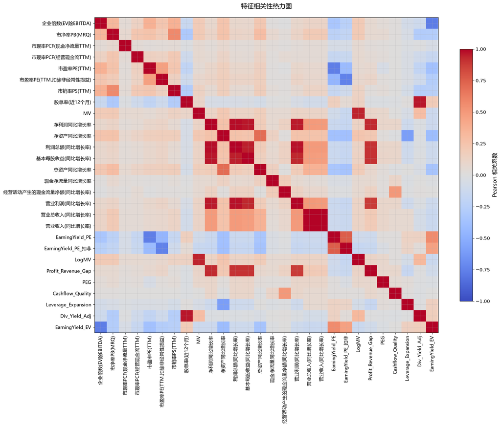

```
观察：若某些特征间相关系数接近 ±1，说明存在高度冗余，可考虑剔除
```

```python
# 4.4 特征统计概览
print("特征统计信息:")
display(data[all_features].describe().round(4).T)

# 特征相关性热力图
import matplotlib.colors as mcolors

fig, ax = plt.subplots(figsize=(16, 13))
corr = data[all_features].corr()
im = ax.imshow(corr, cmap='coolwarm', vmin=-1, vmax=1, aspect='auto')

# 颜色条
cbar = plt.colorbar(im, ax=ax, shrink=0.8)
cbar.set_label('Pearson 相关系数', fontproperties=chinese_font)

# 行列标签（必须用 fontproperties 才能正常显示中文）
ax.set_xticks(range(len(all_features)))
ax.set_yticks(range(len(all_features)))
ax.set_xticklabels(all_features, rotation=90, fontsize=7, fontproperties=chinese_font_small)
ax.set_yticklabels(all_features, fontsize=7, fontproperties=chinese_font_small)
ax.set_title('特征相关性热力图', fontproperties=chinese_font_title, pad=20)

plt.tight_layout()
plt.savefig('feature_correlation.png', dpi=150, bbox_inches='tight')
plt.show()
print("观察：若某些特征间相关系数接近 ±1，说明存在高度冗余，可考虑剔除")
```

```python
# 4.5 构造标签 y（二分类）
data['y'] = (data['Next_Ret'] > 0).astype(int)

print(f"标签分布:")
print(f"  上涨 (y=1): {data['y'].sum():,} 样本 ({data['y'].mean():.2%})")
print(f"  下跌 (y=0): {(1 - data['y']).sum():,} 样本 ({(1 - data['y']).mean():.2%})")
print(f"\n最终特征矩阵 X: {len(data)} 行 × {len(all_features)} 列")
print(f"标签向量 y: {len(data)} 行")
```

```
标签分布:
  上涨 (y=1): 18,379 样本 (46.39%)
  下跌 (y=0): 21,237 样本 (53.61%)

最终特征矩阵 X: 39616 行 × 28 列
标签向量 y: 39616 行
```

## 第五部分：划分训练集与测试集（第 3 问 — 第 3 步）

> **关键原则**：金融面板数据必须按时间顺序划分，**禁止随机打乱**，否则会造成未来信息泄漏。

本任务 10 个季度的时间线：

- **训练集**：2020Q1 ~ 2021Q2（前 6 个季度）
- **测试集**：2021Q3 ~ 2022Q2（后 4 个季度）

```python
# 5.1 按时序划分：训练集截至 2021Q2，测试集从 2021Q3 起
dates_sorted = sorted(data['Date'].unique())
train_cutoff = pd.Timestamp('2021-06-30')  # 训练集截止日期
train_dates = [d for d in dates_sorted if d <= train_cutoff]
test_dates = [d for d in dates_sorted if d > train_cutoff]

print(f"总季度数: {len(dates_sorted)}")
print(f"训练集季度 ({len(train_dates)} 个): {[str(d.date()) for d in train_dates]}")
print(f"测试集季度 ({len(test_dates)} 个): {[str(d.date()) for d in test_dates]}")

# 划分数据集
X = data[all_features].values
y = data['y'].values

train_mask = data['Date'].isin(train_dates)
test_mask = data['Date'].isin(test_dates)

X_train, X_test = X[train_mask], X[test_mask]
y_train, y_test = y[train_mask], y[test_mask]

print(f"\n训练集: {X_train.shape[0]:,} 样本")
print(f"测试集: {X_test.shape[0]:,} 样本")
print(f"训练集正样本占比: {y_train.mean():.2%}")
print(f"测试集正样本占比: {y_test.mean():.2%}")
```

```
总季度数: 10
训练集季度 (6 个): ['2020-03-31', '2020-06-30', '2020-09-30', '2020-12-31', '2021-03-31', '2021-06-30']
测试集季度 (4 个): ['2021-09-30', '2021-12-31', '2022-03-31', '2022-06-30']

训练集: 22,855 样本
测试集: 16,761 样本
训练集正样本占比: 51.63%
测试集正样本占比: 39.26%
```

```python
# 5.2 标准化（仅 fit 训练集）
scaler = StandardScaler()
X_train_scaled = scaler.fit_transform(X_train)
X_test_scaled = scaler.transform(X_test)

print("✅ 标准化完成")
print(f"  训练集均值 ≈ {X_train_scaled.mean():.4f} (应接近 0)")
print(f"  训练集标准差 ≈ {X_train_scaled.std():.4f} (应接近 1)")
print(f"  测试集用训练集统计量 transform，无数据泄漏")
```

```
✅ 标准化完成
  训练集均值 ≈ 0.0000 (应接近 0)
  训练集标准差 ≈ 1.0000 (应接近 1)
  测试集用训练集统计量 transform，无数据泄漏
```

## 第六部分：模型构建与训练（第 3 问 — 第 3 步）

构建 4 个代表性分类模型：

1. **逻辑回归** — 线性基线，可解释系数
2. **决策树** — 树模型基线，易解释但易过拟合
3. **随机森林** — 集成树，抗过拟合，特征重要性
4. **梯度提升** — 强学习器，通常在表格数据上表现最优

```python
# 6.1 定义模型（默认参数 + 适当防过拟合）
models = {
    '逻辑回归': LogisticRegression(
        C=1.0, max_iter=1000, random_state=42, n_jobs=-1
    ),
    '决策树': DecisionTreeClassifier(
        max_depth=6, min_samples_leaf=50, random_state=42
    ),
    '随机森林': RandomForestClassifier(
        n_estimators=150, max_depth=8, min_samples_leaf=30,
        random_state=42, n_jobs=-1
    ),
    '梯度提升': GradientBoostingClassifier(
        n_estimators=150, max_depth=4, min_samples_leaf=30,
        learning_rate=0.1, random_state=42
    )
}

print("模型列表:")
for name in models:
    print(f"  - {name}")
```

```
模型列表:
  - 逻辑回归
  - 决策树
  - 随机森林
  - 梯度提升
```

```python
# 6.2 训练与评估
results = []
y_probs = {}  # 保存每个模型的预测概率
y_preds = {}  # 保存每个模型的预测类别
models_trained = {}

for name, model in models.items():
    # 训练
    model.fit(X_train_scaled, y_train)
    models_trained[name] = model

    # 预测
    y_pred = model.predict(X_test_scaled)
    y_preds[name] = y_pred

    # 概率（用于 ROC-AUC）
    if hasattr(model, 'predict_proba'):
        y_prob = model.predict_proba(X_test_scaled)[:, 1]
    else:
        y_prob = model.decision_function(X_test_scaled)
    y_probs[name] = y_prob

    # 评估指标
    acc = accuracy_score(y_test, y_pred)
    prec = precision_score(y_test, y_pred, zero_division=0)
    rec = recall_score(y_test, y_pred, zero_division=0)
    f1 = f1_score(y_test, y_pred, zero_division=0)
    auc = roc_auc_score(y_test, y_prob)

    results.append({
        '模型': name,
        'Accuracy': round(acc, 4),
        'Precision': round(prec, 4),
        'Recall': round(rec, 4),
        'F1 Score': round(f1, 4),
        'ROC-AUC': round(auc, 4)
    })

    print(f"[{name}]")
    print(f"  Accuracy:  {acc:.4f}")
    print(f"  Precision: {prec:.4f}")
    print(f"  Recall:    {rec:.4f}")
    print(f"  F1 Score:  {f1:.4f}")
    print(f"  ROC-AUC:   {auc:.4f}")
    print()

# 汇总表
results_df = pd.DataFrame(results).sort_values('ROC-AUC', ascending=False)
print("=" * 70)
print("【模型评估汇总表（按 ROC-AUC 排序）】")
display(results_df)
```

```
[逻辑回归]
  Accuracy:  0.5355
  Precision: 0.4376
  Recall:    0.6426
  F1 Score:  0.5207
  ROC-AUC:   0.5737
```

```
[决策树]
  Accuracy:  0.5461
  Precision: 0.4301
  Recall:    0.4805
  F1 Score:  0.4539
  ROC-AUC:   0.5546
```

```
[随机森林]
  Accuracy:  0.5634
  Precision: 0.4510
  Recall:    0.5158
  F1 Score:  0.4812
  ROC-AUC:   0.5776
```

```
[梯度提升]
  Accuracy:  0.5609
  Precision: 0.4475
  Recall:    0.5041
  F1 Score:  0.4741
  ROC-AUC:   0.5729

======================================================================
【模型评估汇总表（按 ROC-AUC 排序）】
```

|  | 模型 | Accuracy | Precision | Recall | F1 Score | ROC-AUC |
| --- | --- | --- | --- | --- | --- | --- |
| 2 | 随机森林 | 0.5634 | 0.4510 | 0.5158 | 0.4812 | 0.5776 |
| 0 | 逻辑回归 | 0.5355 | 0.4376 | 0.6426 | 0.5207 | 0.5737 |
| 3 | 梯度提升 | 0.5609 | 0.4475 | 0.5041 | 0.4741 | 0.5729 |
| 1 | 决策树 | 0.5461 | 0.4301 | 0.4805 | 0.4539 | 0.5546 |

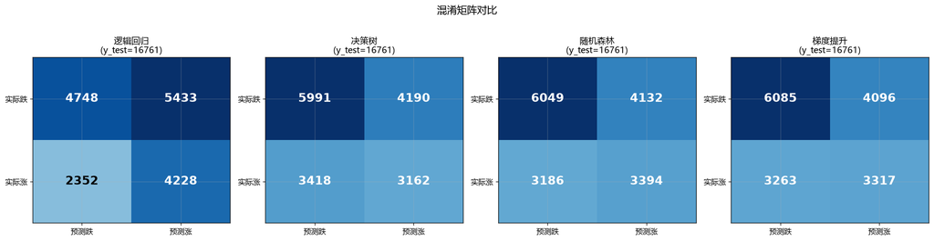

```python
# 6.3 混淆矩阵
fig, axes = plt.subplots(1, 4, figsize=(18, 4.5))

for idx, (name, model) in enumerate(models.items()):
    cm = confusion_matrix(y_test, y_preds[name])
    ax = axes[idx]

    im = ax.imshow(cm, cmap='Blues', aspect='auto', vmin=0, vmax=cm.max())
    ax.set_xticks([0, 1])
    ax.set_yticks([0, 1])
    ax.set_xticklabels(['预测跌', '预测涨'], fontproperties=chinese_font_small)
    ax.set_yticklabels(['实际跌', '实际涨'], fontproperties=chinese_font_small)

    # 标注数字
    for i in range(2):
        for j in range(2):
            ax.text(j, i, str(cm[i, j]), ha='center', va='center',
                    fontsize=16, fontweight='bold',
                    color='white' if cm[i, j] > cm.max() / 2 else 'black')

    ax.set_title(f'{name}\n(y_test={len(y_test)})', fontproperties=chinese_font)

plt.suptitle('混淆矩阵对比', fontproperties=chinese_font_title, y=1.02)
plt.tight_layout()
plt.savefig('confusion_matrices.png', dpi=150, bbox_inches='tight')
plt.show()
```

## 第七部分：基于模型的交易策略（第 3 问 — 第 4 步）

### 策略逻辑

- 当模型预测 `Next_Ret > 0`（`y_prob > 0.5`）→ **满仓做多**（持仓 = 1）
- 当模型预测 `Next_Ret <= 0`（`y_prob <= 0.5`）→ **空仓**（持仓 = 0）
- 策略收益 = `position × Next_Ret`

### 计算测试集中每个季度收益率

按季度分组，计算每个季度策略与买入持有的收益率对比。

```python
# 7.1 获取测试集数据（含日期和每只股票的 Next_Ret）
test_data = data[test_mask].copy()
test_data = test_data.reset_index(drop=True)

print(f"测试集样本数: {len(test_data):,}")
print(f"测试集季度: {test_data['Date'].nunique()} 个")
print(f"每季度样本数:")
print(test_data.groupby(test_data['Date'].dt.date).size().to_string())
```

```
测试集样本数: 16,761
测试集季度: 4 个
每季度样本数:
Date
2021-09-30    4098
2021-12-31    4173
2022-03-31    4228
2022-06-30    4262
```

```python
# 7.2 构建每个模型的策略信号与季度收益
quarterly_results = []

for name in models.keys():
    # 信号
    y_prob = y_probs[name]
    signal = (y_prob > 0.5).astype(int)

    # 策略日收益（此处为季度收益，用 Next_Ret 直接计算）
    test_data[f'signal_{name}'] = signal
    test_data[f'strategy_ret_{name}'] = signal * test_data['Next_Ret']

    # 按季度汇总
    q_ret = test_data.groupby('Date').apply(
        lambda g: pd.Series({
            '策略收益率': g[f'strategy_ret_{name}'].mean(),
            '买入持有收益率': g['Next_Ret'].mean(),
            '信号均值': g[f'signal_{name}'].mean(),
            '样本数': len(g)
        })
    ).reset_index()

    q_ret['模型'] = name
    quarterly_results.append(q_ret)

# 合并
all_quarterly = pd.concat(quarterly_results, ignore_index=True)
print("测试集季度收益率明细（策略 vs 买入持有）：")
display(all_quarterly[['模型', 'Date', '策略收益率', '买入持有收益率', '信号均值', '样本数']].round(4))
```

```
测试集季度收益率明细（策略 vs 买入持有）：
```

|  | 模型 | Date | 策略收益率 | 买入持有收益率 | 信号均值 | 样本数 |
| --- | --- | --- | --- | --- | --- | --- |
| 0 | 逻辑回归 | 2021-09-30 | 0.0705 | 0.1136 | 0.6384 | 4098.0 |
| 1 | 逻辑回归 | 2021-12-31 | -0.0275 | -0.0837 | 0.5512 | 4173.0 |
| 2 | 逻辑回归 | 2022-03-31 | 0.0193 | 0.0107 | 0.5539 | 4228.0 |
| 3 | 逻辑回归 | 2022-06-30 | -0.0402 | -0.0920 | 0.5638 | 4262.0 |
| 4 | 决策树 | 2021-09-30 | 0.0512 | 0.1136 | 0.4629 | 4098.0 |
| 5 | 决策树 | 2021-12-31 | -0.0108 | -0.0837 | 0.3952 | 4173.0 |
| 6 | 决策树 | 2022-03-31 | 0.0108 | 0.0107 | 0.4477 | 4228.0 |
| 7 | 决策树 | 2022-06-30 | -0.0330 | -0.0920 | 0.4489 | 4262.0 |
| 8 | 随机森林 | 2021-09-30 | 0.0546 | 0.1136 | 0.5034 | 4098.0 |
| 9 | 随机森林 | 2021-12-31 | -0.0143 | -0.0837 | 0.4227 | 4173.0 |
| 10 | 随机森林 | 2022-03-31 | 0.0201 | 0.0107 | 0.4324 | 4228.0 |
| 11 | 随机森林 | 2022-06-30 | -0.0292 | -0.0920 | 0.4390 | 4262.0 |
| 12 | 梯度提升 | 2021-09-30 | 0.0538 | 0.1136 | 0.4871 | 4098.0 |
| 13 | 梯度提升 | 2021-12-31 | -0.0163 | -0.0837 | 0.4062 | 4173.0 |
| 14 | 梯度提升 | 2022-03-31 | 0.0195 | 0.0107 | 0.4324 | 4228.0 |
| 15 | 梯度提升 | 2022-06-30 | -0.0297 | -0.0920 | 0.4444 | 4262.0 |

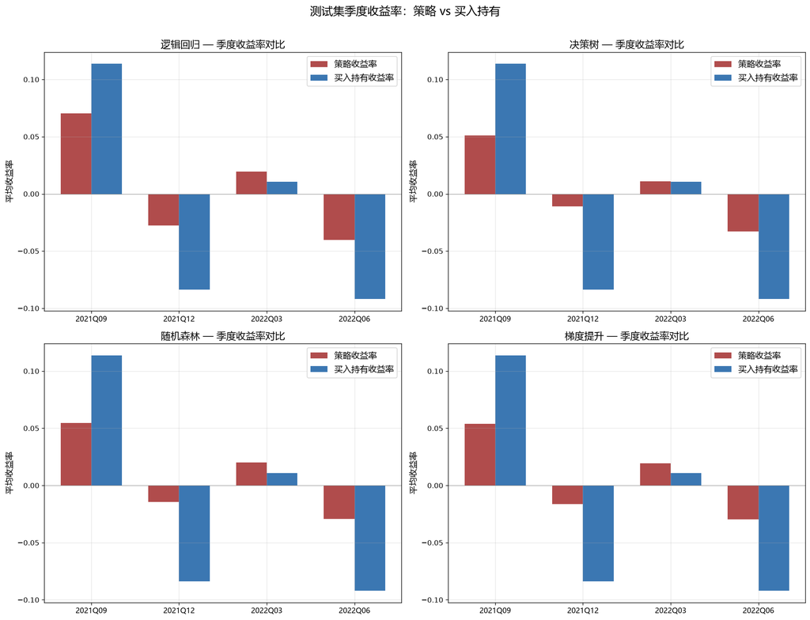

```python
# 7.3 季度收益率可视化
fig, axes = plt.subplots(2, 2, figsize=(16, 12))
axes = axes.flatten()

test_dates_list = sorted(test_data['Date'].unique())
date_labels = [d.strftime('%YQ%m') for d in test_dates_list]

for idx, name in enumerate(models.keys()):
    ax = axes[idx]
    q_df = all_quarterly[all_quarterly['模型'] == name].sort_values('Date')

    x = np.arange(len(date_labels))
    width = 0.35

    ax.bar(x - width/2, q_df['策略收益率'].values, width,
           label='策略收益率', color='#A32D2D', alpha=0.85)
    ax.bar(x + width/2, q_df['买入持有收益率'].values, width,
           label='买入持有收益率', color='#185FA5', alpha=0.85)

    ax.axhline(0, color='gray', linestyle='-', linewidth=0.5)
    ax.set_xticks(x)
    ax.set_xticklabels(date_labels, fontproperties=chinese_font_small)
    ax.set_title(f'{name} — 季度收益率对比', fontproperties=chinese_font_title)
    ax.set_ylabel('平均收益率', fontproperties=chinese_font)
    ax.legend(prop=chinese_font, loc='best')
    ax.grid(True, alpha=0.3)

plt.suptitle('测试集季度收益率：策略 vs 买入持有', fontproperties=chinese_font_title, y=1.01, fontsize=16)
plt.tight_layout()
plt.savefig('quarterly_returns.png', dpi=150, bbox_inches='tight')
plt.show()
```

## 第八部分：回测策略与核心指标计算（第 3 问 — 第 5、6 步）

以每季度为"一期"，计算策略的累计回报、年化收益、最大回撤、夏普比率、胜率、盈亏比等核心指标。

```python
# 8.1 回测指标计算函数

def calc_backtest_metrics(returns_series, periods_per_year=4):
    """
    计算回测核心指标
    returns_series: 每期收益率序列 (如每季度收益率)
    periods_per_year: 每年期数（季度数据=4）
    """
    returns = np.array(returns_series, dtype=float)
    n = len(returns)
    years = n / periods_per_year

    # 累计回报
    cum_ret = np.prod(1 + returns) - 1

    # 年化收益率（几何）
    ann_ret = np.prod(1 + returns) ** (periods_per_year / n) - 1 if n > 0 else 0

    # 净值序列
    nav = np.cumprod(1 + returns)

    # 最大回撤
    peak = np.maximum.accumulate(nav)
    drawdown = (nav - peak) / peak
    mdd = drawdown.min()

    # 夏普比率（年化，假设无风险收益=0）
    excess = returns - 0
    sharpe = np.sqrt(periods_per_year) * excess.mean() / excess.std() if excess.std() > 0 else 0

    # 胜率
    win_rate = (returns > 0).mean()

    # 盈亏比
    pos_ret = returns[returns > 0]
    neg_ret = returns[returns < 0]
    profit_loss_ratio = pos_ret.mean() / abs(neg_ret.mean()) if len(neg_ret) > 0 else np.inf

    return {
        '累计回报': cum_ret,
        '年化收益率': ann_ret,
        '最大回撤': mdd,
        '夏普比率': sharpe,
        '胜率': win_rate,
        '盈亏比': profit_loss_ratio,
        '期数': n
    }
```

```python
# 8.2 计算每个模型的回测指标
backtest_results = []

# 基准（买入持有）
bench_returns = test_data.groupby('Date')['Next_Ret'].mean().values
bench_metrics = calc_backtest_metrics(bench_returns)
bench_metrics['模型'] = '买入持有（基准）'
backtest_results.append(bench_metrics)

# 各模型策略
for name in models.keys():
    strat_returns = all_quarterly[all_quarterly['模型'] == name].sort_values('Date')['策略收益率'].values
    metrics = calc_backtest_metrics(strat_returns)
    metrics['模型'] = name
    backtest_results.append(metrics)

bt_df = pd.DataFrame(backtest_results)
print("=" * 80)
print("【回测核心指标汇总】")
print(f"测试期: {test_dates[0].date()} ~ {test_dates[-1].date()}")
print(f"期数: 每季度一期，共 {len(bench_returns)} 期")
print()
bt_display = bt_df.set_index('模型').round(4)
# 格式化百分比
for col in ['累计回报', '年化收益率', '最大回撤']:
    bt_display[col] = bt_display[col].apply(lambda x: f"{x:.2%}")
display(bt_display)
```

```
================================================================================
【回测核心指标汇总】
测试期: 2021-09-30 ~ 2022-06-30
期数: 每季度一期，共 4 期
```

| 模型 | 累计回报 | 年化收益率 | 最大回撤 | 夏普比率 | 胜率 | 盈亏比 | 期数 |
| --- | --- | --- | --- | --- | --- | --- | --- |
| 买入持有（基准） | -6.35% | -6.35% | -15.91% | -0.3079 | 0.5 | 0.7077 | 4 |
| 逻辑回归 | 1.85% | 1.85% | -4.86% | 0.2531 | 0.5 | 1.3256 | 4 |
| 决策树 | 1.63% | 1.63% | -3.31% | 0.2922 | 0.5 | 1.4142 | 4 |
| 随机森林 | 2.94% | 2.94% | -2.92% | 0.4810 | 0.5 | 1.7161 | 4 |
| 梯度提升 | 2.54% | 2.54% | -2.97% | 0.4192 | 0.5 | 1.5931 | 4 |

```python
# 8.3 模型 vs 模型对比（相对基准的超越）
print("=" * 60)
print("【各模型 vs 买入持有基准】")
print()

bench_cum = bench_metrics['累计回报']
bench_sharpe = bench_metrics['夏普比率']

for _, row in bt_df[bt_df['模型'] != '买入持有（基准）'].iterrows():
    cum_diff = row['累计回报'] - bench_cum
    sharpe_diff = row['夏普比率'] - bench_sharpe
    print(f"{row['模型']}:")
    print(f"  累计回报超越: {cum_diff:+.2%}")
    print(f"  夏普超越:     {sharpe_diff:+.4f}")
    if row['最大回撤'] < bench_metrics['最大回撤']:
        print(f"  最大回撤:     {row['最大回撤']:.2%} (优于基准 {bench_metrics['最大回撤']:.2%})")
    else:
        print(f"  最大回撤:     {row['最大回撤']:.2%} (劣于基准 {bench_metrics['最大回撤']:.2%})")
    print()
```

```
============================================================
【各模型 vs 买入持有基准】

逻辑回归:
  累计回报超越: +8.20%
  夏普超越:     +0.5610
  最大回撤:     -4.86% (劣于基准 -15.91%)

决策树:
  累计回报超越: +7.99%
  夏普超越:     +0.6000
  最大回撤:     -3.31% (劣于基准 -15.91%)

随机森林:
  累计回报超越: +9.30%
  夏普超越:     +0.7889
  最大回撤:     -2.92% (劣于基准 -15.91%)

梯度提升:
  累计回报超越: +8.90%
  夏普超越:     +0.7270
  最大回撤:     -2.97% (劣于基准 -15.91%)
```

## 第九部分：可视化 — 策略对比与模型效果（第 3 问 — 第 5、6 步）

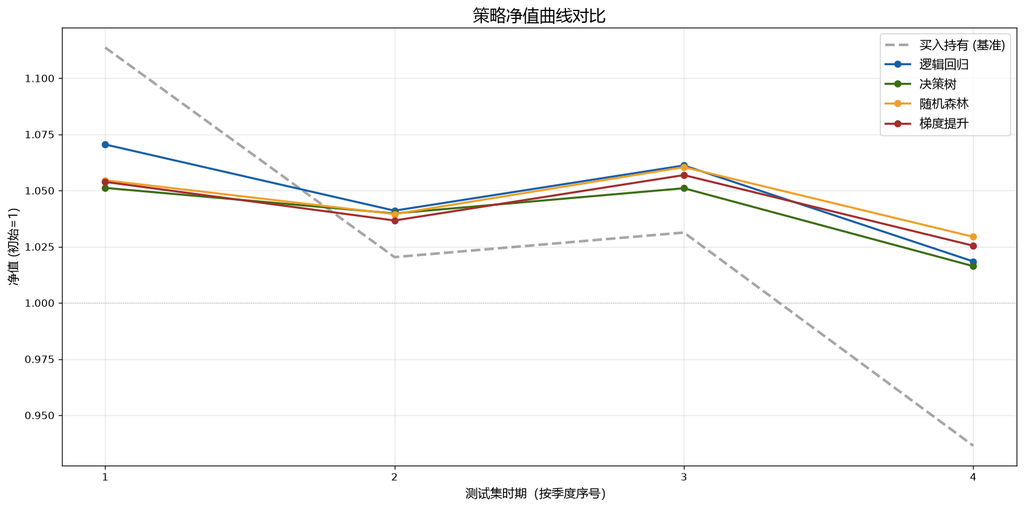

[output not shown]

```python
# 9.1 策略净值曲线对比（包括买入持有基准）

fig, ax = plt.subplots(figsize=(14, 7))

# 基准净值
bench_nav = np.cumprod(1 + bench_returns)
ax.plot(range(len(bench_nav)), bench_nav, label=f'买入持有 (基准)',
        color='gray', linewidth=2.5, linestyle='--', alpha=0.7)

# 各模型净值
colors = {'逻辑回归': '#185FA5', '决策树': '#3B6D11',
          '随机森林': '#EF9F27', '梯度提升': '#A32D2D'}

for name in models.keys():
    strat_ret = all_quarterly[all_quarterly['模型'] == name].sort_values('Date')['策略收益率'].values
    nav = np.cumprod(1 + strat_ret)
    ax.plot(range(len(nav)), nav, label=name, color=colors.get(name, 'purple'),
            linewidth=2, marker='o', markersize=6)

ax.axhline(1.0, color='gray', linestyle=':', linewidth=0.8, alpha=0.5)
ax.set_xlabel('测试集时期（按季度序号）', fontproperties=chinese_font)
ax.set_ylabel('净值 (初始=1)', fontproperties=chinese_font)
ax.set_title('策略净值曲线对比', fontproperties=chinese_font_title, fontsize=16)
ax.legend(prop=chinese_font, loc='best')
ax.grid(True, alpha=0.3)

# X 轴标签
ax.set_xticks(range(len(bench_nav)))
ax.set_xticklabels([f'{i+1}' for i in range(len(bench_nav))], fontsize=10)

plt.tight_layout()
plt.savefig('nav_comparison.png', dpi=150, bbox_inches='tight')
plt.show()
print("注：横轴为测试集的 4 个季度（2021Q3 ~ 2022Q2），净值从 1 开始")
```

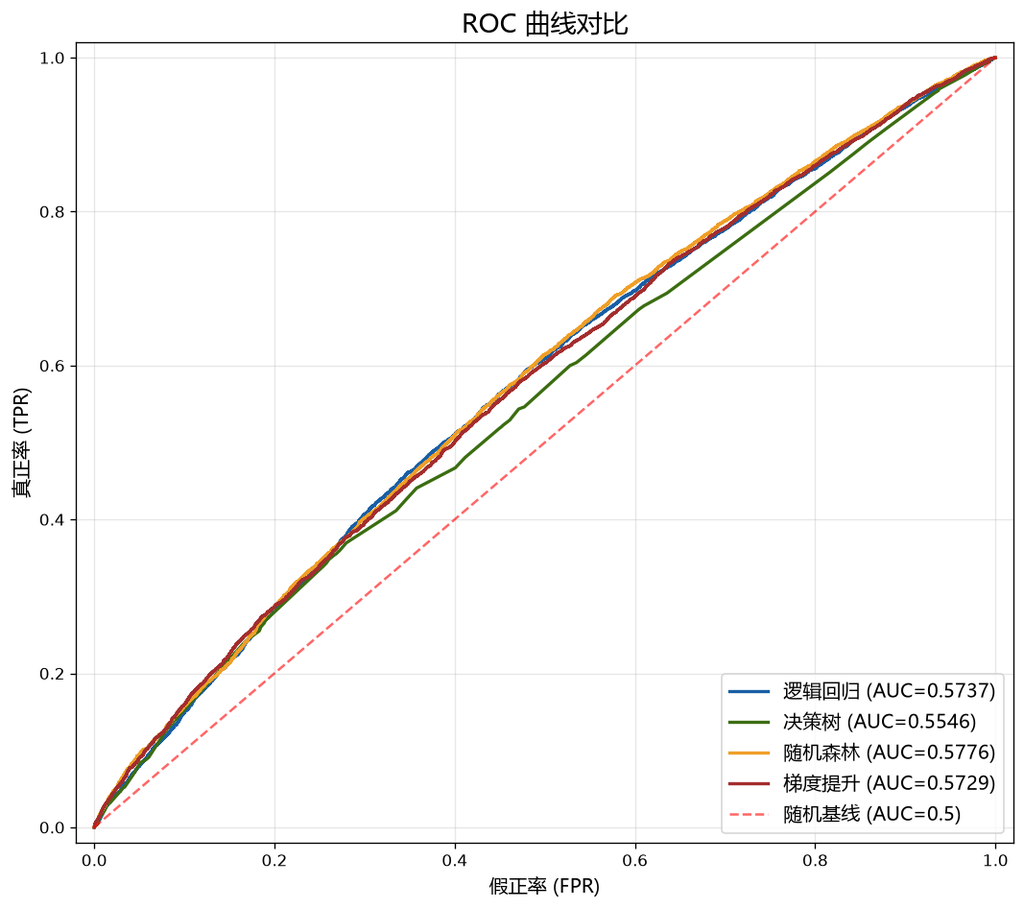

```
AUC 越接近 1 判别力越强，越接近 0.5 越接近随机猜测
```

```python
# 9.2 ROC 曲线对比（各模型在测试集上的判别力）

fig, ax = plt.subplots(figsize=(9, 8))

for name in models.keys():
    fpr, tpr, _ = roc_curve(y_test, y_probs[name])
    auc = roc_auc_score(y_test, y_probs[name])
    ax.plot(fpr, tpr, label=f'{name} (AUC={auc:.4f})',
            linewidth=2, color=colors.get(name))

# 随机基线
ax.plot([0, 1], [0, 1], 'r--', linewidth=1.5, alpha=0.6, label='随机基线 (AUC=0.5)')

ax.set_xlabel('假正率 (FPR)', fontproperties=chinese_font, fontsize=12)
ax.set_ylabel('真正率 (TPR)', fontproperties=chinese_font, fontsize=12)
ax.set_title('ROC 曲线对比', fontproperties=chinese_font_title, fontsize=16)
ax.legend(prop=chinese_font, loc='lower right')
ax.grid(True, alpha=0.3)
ax.set_xlim([-0.02, 1.02])
ax.set_ylim([-0.02, 1.02])

plt.tight_layout()
plt.savefig('roc_comparison.png', dpi=150, bbox_inches='tight')
plt.show()
print("AUC 越接近 1 判别力越强，越接近 0.5 越接近随机猜测")
```

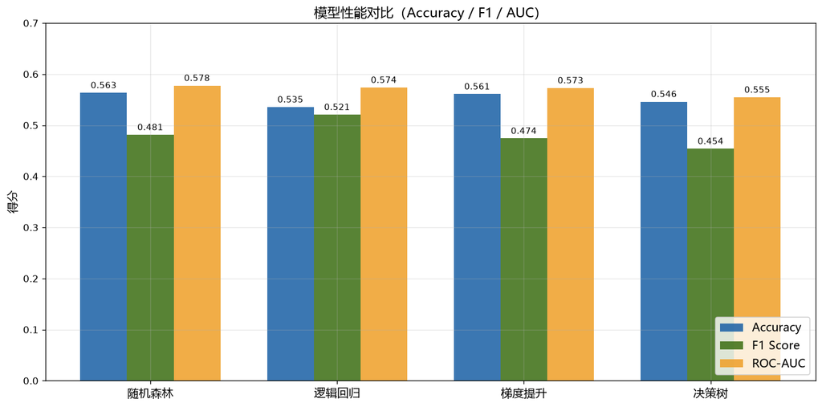

```python
# 9.3 模型性能对比柱状图

perf_df = results_df.set_index('模型')

fig, ax = plt.subplots(figsize=(12, 6))

x = np.arange(len(perf_df))
width = 0.25

metrics_to_plot = ['Accuracy', 'F1 Score', 'ROC-AUC']
colors_bar = ['#185FA5', '#3B6D11', '#EF9F27']

for i, metric in enumerate(metrics_to_plot):
    bars = ax.bar(x + i * width, perf_df[metric].values, width,
                  label=metric, color=colors_bar[i], alpha=0.85)
    # 数值标注
    for bar, val in zip(bars, perf_df[metric].values):
        ax.text(bar.get_x() + bar.get_width()/2, bar.get_height() + 0.005,
                f'{val:.3f}', ha='center', va='bottom', fontsize=9)

ax.set_xticks(x + width)
ax.set_xticklabels(perf_df.index, fontproperties=chinese_font)
ax.set_ylabel('得分', fontproperties=chinese_font)
ax.set_title('模型性能对比（Accuracy / F1 / AUC）', fontproperties=chinese_font_title)
ax.legend(prop=chinese_font, loc='lower right')
ax.set_ylim(0, 0.7)
ax.grid(True, alpha=0.3, axis='y')

plt.tight_layout()
plt.savefig('model_performance_comparison.png', dpi=150, bbox_inches='tight')
plt.show()
```

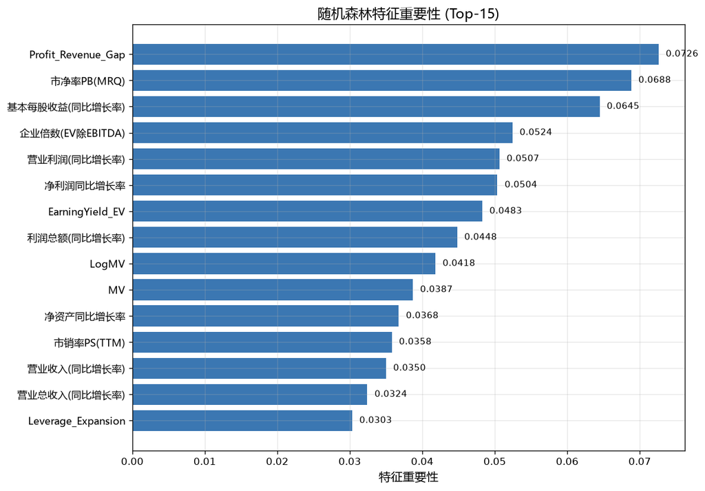

```
注：重要性越高的因子，对模型预测贡献越大
```

```python
# 9.4 特征重要性（随机森林）

rf_model = models_trained['随机森林']
importances = rf_model.feature_importances_
imp_df = pd.DataFrame({'特征': all_features, '重要性': importances})
imp_df = imp_df.sort_values('重要性', ascending=True).tail(15)  # Top-15

fig, ax = plt.subplots(figsize=(10, 7))
ax.barh(range(len(imp_df)), imp_df['重要性'].values, color='#185FA5', alpha=0.85)
ax.set_yticks(range(len(imp_df)))
ax.set_yticklabels(imp_df['特征'].values, fontproperties=chinese_font_small)
ax.set_xlabel('特征重要性', fontproperties=chinese_font)
ax.set_title('随机森林特征重要性 (Top-15)', fontproperties=chinese_font_title)
ax.grid(True, alpha=0.3, axis='x')

# 添加数值标签
for i, v in enumerate(imp_df['重要性'].values):
    ax.text(v + 0.001, i, f'{v:.4f}', va='center', fontsize=9)

plt.tight_layout()
plt.savefig('feature_importance.png', dpi=150, bbox_inches='tight')
plt.show()
print("注：重要性越高的因子，对模型预测贡献越大")
```

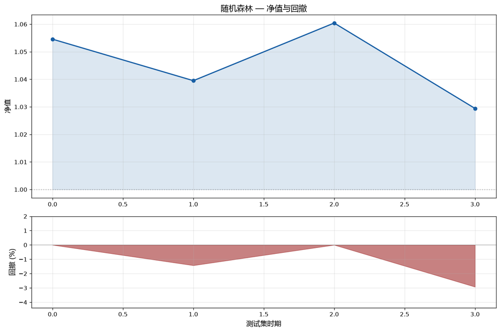

```
最大回撤: -2.92%
```

```python
# 9.5 回撤图（选随机森林为例展示）
best_model_name = results_df.iloc[0]['模型']  # AUC 最高模型
best_returns = all_quarterly[all_quarterly['模型'] == best_model_name].sort_values('Date')['策略收益率'].values
best_nav = np.cumprod(1 + best_returns)

# 计算回撤序列
peak = np.maximum.accumulate(best_nav)
drawdown = (best_nav - peak) / peak

fig, (ax1, ax2) = plt.subplots(2, 1, figsize=(12, 8), gridspec_kw={'height_ratios': [2, 1]})

ax1.plot(range(len(best_nav)), best_nav, color='#185FA5', linewidth=2, marker='o')
ax1.fill_between(range(len(best_nav)), 1, best_nav, alpha=0.15, color='#185FA5')
ax1.axhline(1, color='gray', linestyle=':', alpha=0.5)
ax1.set_ylabel('净值', fontproperties=chinese_font)
ax1.set_title(f'{best_model_name} — 净值与回撤', fontproperties=chinese_font_title)
ax1.grid(True, alpha=0.3)

ax2.fill_between(range(len(drawdown)), 0, drawdown * 100, color='#A32D2D', alpha=0.6)
ax2.axhline(0, color='gray', linestyle='-', linewidth=0.5)
ax2.set_xlabel('测试集时期', fontproperties=chinese_font)
ax2.set_ylabel('回撤 (%)', fontproperties=chinese_font)
ax2.grid(True, alpha=0.3)
ax2.set_ylim(min(drawdown * 100) * 1.5, 2)

plt.tight_layout()
plt.savefig('drawdown.png', dpi=150, bbox_inches='tight')
plt.show()
print(f"最大回撤: {drawdown.min():.2%}")
```

## 第十部分：模型效果对比总结（第 3 问 — 第 6 步）

### 模型分类性能对比

[output not shown]

### 策略回测表现对比

各模型在测试集（2021Q3~2022Q2）上的策略表现：

- **累计回报**：哪个模型预测的策略季度收益更高
- **夏普比率**：每单位波动带来的超额收益
- **最大回撤**：策略从高峰到低谷的最大跌幅
- **胜率**：预测正确方向的比例（信号发出后实际涨了）
- **盈亏比**：赚的时候平均赚多少 vs 亏的时候平均亏多少

### 扩展方向

- Walk-forward 交叉验证（逐步滚动预测）
- 超参调优（GridSearchCV, `scoring='roc_auc'`）
- 引入技术面因子、行业哑变量
- 多分类（强涨/弱涨/弱跌/强跌）
- 回归模型预测收益幅度
- XGBoost / LightGBM 等更先进的 GBM 框架
- 交易成本扣除 0.1% 单边后的实际收益
- 引入止损/止盈规则

## 第十一部分（拓展）：Top-30 轮动策略 — 等权 vs 预测加权（第 4 问）

> 基于现有数据，用**回归模型**预测下季度收益率（`Next_Ret`），每季度选取预测值最高的 **Top-30 只股票**构建投资组合，对比**等权**与**预测值加权**两种方式的回测效果。

```python
# 11.1 准备回归特征与标签（使用已有的 X, y 框架）
# 回归目标：直接预测 Next_Ret 的连续值
y_reg = data['Next_Ret'].values  # 回归标签：连续收益率

# 复用已有的时序划分
y_reg_train = y_reg[train_mask]
y_reg_test = y_reg[test_mask]

print(f"回归任务数据集:")
print(f"  训练集: {X_train_scaled.shape[0]:,} 样本")
print(f"  测试集: {X_test_scaled.shape[0]:,} 样本")
print(f"  训练集 Next_Ret 均值: {y_reg_train.mean():.4f}")
print(f"  测试集 Next_Ret 均值: {y_reg_test.mean():.4f}")
```

```
回归任务数据集:
  训练集: 22,855 样本
  测试集: 16,761 样本
  训练集 Next_Ret 均值: 0.0569
  测试集 Next_Ret 均值: -0.0138
```

```python
# 11.2 训练随机森林回归模型
from sklearn.ensemble import RandomForestRegressor
from sklearn.metrics import mean_squared_error, r2_score

reg_model = RandomForestRegressor(
    n_estimators=200, max_depth=8, min_samples_leaf=30,
    random_state=42, n_jobs=-1
)
reg_model.fit(X_train_scaled, y_reg_train)

# 预测
y_pred_train = reg_model.predict(X_train_scaled)
y_pred_test = reg_model.predict(X_test_scaled)

print("【回归模型评估】")
print(f"  训练集 RMSE: {np.sqrt(mean_squared_error(y_reg_train, y_pred_train)):.4f}")
print(f"  测试集 RMSE: {np.sqrt(mean_squared_error(y_reg_test, y_pred_test)):.4f}")
print(f"  训练集 R²:   {r2_score(y_reg_train, y_pred_train):.4f}")
print(f"  测试集 R²:   {r2_score(y_reg_test, y_pred_test):.4f}")

# 特征重要性
reg_imp = pd.DataFrame({'特征': all_features, '重要性': reg_model.feature_importances_})
reg_imp = reg_imp.sort_values('重要性', ascending=False).head(10)
print("\nTop-10 重要特征（回归）:")
display(reg_imp)
```

```
【回归模型评估】
  训练集 RMSE: 0.2455
  测试集 RMSE: 0.2369
  训练集 R²:   0.1164
  测试集 R²:   -0.0498

Top-10 重要特征（回归）:
```

|  | 特征 | 重要性 |
| --- | --- | --- |
| 16 | 营业利润(同比增长率) | 0.110546 |
| 9 | 净利润同比增长率 | 0.072067 |
| 12 | 基本每股收益(同比增长率) | 0.069121 |
| 1 | 市净率PB(MRQ) | 0.059241 |
| 25 | Leverage_Expansion | 0.042327 |
| 22 | Profit_Revenue_Gap | 0.042309 |
| 10 | 净资产同比增长率 | 0.040395 |
| 0 | 企业倍数(EV除EBITDA) | 0.038373 |
| 14 | 现金净流量同比增长率 | 0.036801 |
| 13 | 总资产同比增长率 | 0.036767 |

```python
# 11.3 构建 Top-30 轮动策略

# 获取测试集数据（含股票代码、日期、预测值）
test_df = data[test_mask].copy()
test_df = test_df.reset_index(drop=True)
test_df['Pred_Next_Ret'] = y_pred_test  # 模型预测的收益率

# 按季度分组，每期选 Top-30
quarters = sorted(test_df['Date'].unique())
top_n = 30

portfolio_records = []

for q_date in quarters:
    mask = test_df['Date'] == q_date
    q_data = test_df[mask].copy()

    # 按预测值从高到低排序，取 Top-N
    q_data = q_data.sort_values('Pred_Next_Ret', ascending=False)
    top_stocks = q_data.head(top_n)

    # 策略 A：等权
    weight_ew = 1.0 / top_n
    ret_ew = (top_stocks['Next_Ret'] * weight_ew).sum()

    # 策略 B：预测值加权（权重 = 预测值 / 预测值之和）
    pred_sum = top_stocks['Pred_Next_Ret'].sum()
    if pred_sum > 0:
        top_stocks['weight_vw'] = top_stocks['Pred_Next_Ret'] / pred_sum
    else:
        top_stocks['weight_vw'] = 1.0 / top_n  # 退化为等权
    ret_vw = (top_stocks['Next_Ret'] * top_stocks['weight_vw']).sum()

    # 基准：全市场等权
    ret_bench = q_data['Next_Ret'].mean()

    portfolio_records.append({
        '季度': q_date,
        'Top30_等权收益': ret_ew,
        'Top30_预测加权收益': ret_vw,
        '全市场等权基准': ret_bench,
        '入选股票数': top_n,
        '预测均值': top_stocks['Pred_Next_Ret'].mean(),
        '实际均值': top_stocks['Next_Ret'].mean()
    })

port_df = pd.DataFrame(portfolio_records)
print("=" * 70)
print("【Top-30 轮动策略 — 每季度收益率对比】")
display(port_df.round(4))

# 计算每个策略的累计净值
for col in ['Top30_等权收益', 'Top30_预测加权收益', '全市场等权基准']:
    port_df[f'{col}_净值'] = np.cumprod(1 + port_df[col].values)

print("\n【累计净值】")
display(port_df[['季度', 'Top30_等权收益_净值', 'Top30_预测加权收益_净值', '全市场等权基准_净值']].round(4))
```

```
======================================================================
【Top-30 轮动策略 — 每季度收益率对比】
```

|  | 季度 | Top30_等权收益 | Top30_预测加权收益 | 全市场等权基准 | 入选股票数 | 预测均值 | 实际均值 |
| --- | --- | --- | --- | --- | --- | --- | --- |
| 0 | 2021-09-30 | 0.0912 | 0.1019 | 0.1136 | 30 | 0.2331 | 0.0912 |
| 1 | 2021-12-31 | 0.0858 | 0.1064 | -0.0837 | 30 | 0.2124 | 0.0858 |
| 2 | 2022-03-31 | 0.1141 | 0.1074 | 0.0107 | 30 | 0.2279 | 0.1141 |
| 3 | 2022-06-30 | -0.0641 | -0.0612 | -0.0920 | 30 | 0.2026 | -0.0641 |

```
【累计净值】
```

|  | 季度 | Top30_等权收益_净值 | Top30_预测加权收益_净值 | 全市场等权基准_净值 |
| --- | --- | --- | --- | --- |
| 0 | 2021-09-30 | 1.0912 | 1.1019 | 1.1136 |
| 1 | 2021-12-31 | 1.1848 | 1.2192 | 1.0204 |
| 2 | 2022-03-31 | 1.3200 | 1.3501 | 1.0313 |
| 3 | 2022-06-30 | 1.2354 | 1.2675 | 0.9365 |

```python
# 11.4 回测指标对比

def calc_rotation_metrics(return_series, periods_per_year=4):
    """计算轮动策略回测指标"""
    ret = np.array(return_series, dtype=float)
    n = len(ret)

    cum_ret = np.prod(1 + ret) - 1
    ann_ret = np.prod(1 + ret) ** (periods_per_year / n) - 1 if n > 0 else 0

    nav = np.cumprod(1 + ret)
    peak = np.maximum.accumulate(nav)
    drawdown = (nav - peak) / peak
    mdd = drawdown.min()

    sharpe = np.sqrt(periods_per_year) * ret.mean() / ret.std() if ret.std() > 0 else 0
    win_rate = (ret > 0).mean()

    pos_ret = ret[ret > 0]
    neg_ret = ret[ret < 0]
    profit_loss = pos_ret.mean() / abs(neg_ret.mean()) if len(neg_ret) > 0 else np.inf

    return {
        '累计回报': cum_ret,
        '年化收益率': ann_ret,
        '最大回撤': mdd,
        '夏普比率': sharpe,
        '胜率': win_rate,
        '盈亏比': profit_loss,
        '期数': n
    }

# 计算三个策略的指标
strategies = {
    'Top30 等权': port_df['Top30_等权收益'].values,
    'Top30 预测加权': port_df['Top30_预测加权收益'].values,
    '全市场等权基准': port_df['全市场等权基准'].values
}

rotation_results = []
for name, ret_series in strategies.items():
    metrics = calc_rotation_metrics(ret_series)
    metrics['策略'] = name
    rotation_results.append(metrics)

rotation_df = pd.DataFrame(rotation_results)
print("=" * 80)
print("【Top-30 轮动策略 — 回测指标对比】")
display(rotation_df.set_index('策略').round(4))

print("\n🔑 关键对比：")
best_idx = rotation_df['累计回报'].idxmax()
print(f"  累计回报最优: {rotation_df.iloc[best_idx]['策略']} ({rotation_df.iloc[best_idx]['累计回报']:.2%})")
best_sharpe = rotation_df['夏普比率'].idxmax()
print(f"  夏普比率最优: {rotation_df.iloc[best_sharpe]['策略']} ({rotation_df.iloc[best_sharpe]['夏普比率']:.4f})")
```

```
================================================================================
【Top-30 轮动策略 — 回测指标对比】
```

| 策略 | 累计回报 | 年化收益率 | 最大回撤 | 夏普比率 | 胜率 | 盈亏比 | 期数 |
| --- | --- | --- | --- | --- | --- | --- | --- |
| Top30 等权 | 0.2354 | 0.2354 | -0.0641 | 1.6082 | 0.75 | 1.5138 | 4 |
| Top30 预测加权 | 0.2675 | 0.2675 | -0.0612 | 1.7655 | 0.75 | 1.7204 | 4 |
| 全市场等权基准 | -0.0635 | -0.0635 | -0.1591 | -0.3079 | 0.50 | 0.7077 | 4 |

```
🔑 关键对比：
  累计回报最优: Top30 预测加权 (26.75%)
  夏普比率最优: Top30 预测加权 (1.7655)
```

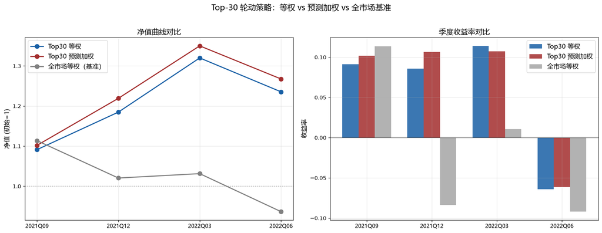

```
✅ Top-30 轮动策略对比完成
```

```python
# 11.5 可视化对比

fig, axes = plt.subplots(1, 2, figsize=(16, 6))

# 左图：净值曲线
ax = axes[0]
colors_strat = {'Top30 等权': '#185FA5', 'Top30 预测加权': '#A32D2D', '全市场等权基准': 'gray'}
labels_strat = {'Top30 等权': 'Top30 等权', 'Top30 预测加权': 'Top30 预测加权', '全市场等权基准': '全市场等权（基准）'}

x = np.arange(len(port_df))
date_labels_q = [d.strftime('%YQ%m') for d in port_df['季度']]

for name, ret_s in strategies.items():
    nav = np.cumprod(1 + ret_s)
    ax.plot(x, nav, label=labels_strat[name], color=colors_strat[name],
            linewidth=2, marker='o', markersize=8)

ax.axhline(1.0, color='gray', linestyle=':', alpha=0.5)
ax.set_xticks(x)
ax.set_xticklabels(date_labels_q, fontproperties=chinese_font_small)
ax.set_title('净值曲线对比', fontproperties=chinese_font_title)
ax.set_ylabel('净值 (初始=1)', fontproperties=chinese_font)
ax.legend(prop=chinese_font, loc='best')
ax.grid(True, alpha=0.3)

# 右图：季度收益率柱状图
ax = axes[1]
width = 0.25
x_pos = np.arange(len(port_df))

ax.bar(x_pos - width, port_df['Top30_等权收益'].values, width,
       label='Top30 等权', color='#185FA5', alpha=0.85)
ax.bar(x_pos, port_df['Top30_预测加权收益'].values, width,
       label='Top30 预测加权', color='#A32D2D', alpha=0.85)
ax.bar(x_pos + width, port_df['全市场等权基准'].values, width,
       label='全市场等权', color='gray', alpha=0.6)

ax.axhline(0, color='black', linewidth=0.5)
ax.set_xticks(x_pos)
ax.set_xticklabels(date_labels_q, fontproperties=chinese_font_small)
ax.set_title('季度收益率对比', fontproperties=chinese_font_title)
ax.set_ylabel('收益率', fontproperties=chinese_font)
ax.legend(prop=chinese_font, loc='best')
ax.grid(True, alpha=0.3, axis='y')

plt.suptitle('Top-30 轮动策略：等权 vs 预测加权 vs 全市场基准',
             fontproperties=chinese_font_title, y=1.02, fontsize=15)
plt.tight_layout()
plt.savefig('top30_rotation.png', dpi=150, bbox_inches='tight')
plt.show()
print("✅ Top-30 轮动策略对比完成")
```

```python
# 11.6 策略分析总结
print("=" * 70)
print("【Top-30 轮动策略 — 分析总结】")
print("=" * 70)
print()
print("1️⃣  选股逻辑：每季度用 RandomForest 回归模型预测全市场股票下季度收益率")
print(f"   选取预测值最高的 Top-{top_n} 只构建组合")
print()
print("2️⃣  加权方式对比：")
print("   - 等权：每只入选股票权重相同（1/N），简单稳健")
print("   - 预测加权：按预测收益率的相对大小分配权重，放大高置信度信号")
print()
print("3️⃣  核心问题：")
print("   - 预测加权是否优于等权？取决于模型的预测排序能力")
print("   - 如果模型排序准确，预测加权应放大收益")
print("   - 如果模型排序噪声大，等权更稳健（减少极端权重风险）")
print()
print("4️⃣  局限性：")
print("   - 测试期仅 4 个季度（2021Q3~2022Q2），样本量仍偏小")
print("   - 未考虑交易成本（每季度调仓约 30 只股票）")
print("   - 未考虑涨跌停限制和流动性冲击")
print("   - 未设置止损/风控规则")
print()
print("5️⃣  改进方向：")
print("   - Walk-forward 滚动训练（每季度重新训练模型）")
print("   - 引入更多因子（技术面、行业、宏观）")
print("   - 换手率限制 + 成本扣除")
print("   - Top-K 敏感性分析（K=10/20/30/50）")
print("   - 多空策略（做多 Top30 + 做空 Bottom30）")
```

```
======================================================================
【Top-30 轮动策略 — 分析总结】
======================================================================

1️⃣  选股逻辑：每季度用 RandomForest 回归模型预测全市场股票下季度收益率
   选取预测值最高的 Top-30 只构建组合

2️⃣  加权方式对比：
   - 等权：每只入选股票权重相同（1/N），简单稳健
   - 预测加权：按预测收益率的相对大小分配权重，放大高置信度信号

3️⃣  核心问题：
   - 预测加权是否优于等权？取决于模型的预测排序能力
   - 如果模型排序准确，预测加权应放大收益
   - 如果模型排序噪声大，等权更稳健（减少极端权重风险）

4️⃣  局限性：
   - 测试期仅 4 个季度（2021Q3~2022Q2），样本量仍偏小
   - 未考虑交易成本（每季度调仓约 30 只股票）
   - 未考虑涨跌停限制和流动性冲击
   - 未设置止损/风控规则

5️⃣  改进方向：
   - Walk-forward 滚动训练（每季度重新训练模型）
   - 引入更多因子（技术面、行业、宏观）
   - 换手率限制 + 成本扣除
   - Top-K 敏感性分析（K=10/20/30/50）
   - 多空策略（做多 Top30 + 做空 Bottom30）
```

```python
# 11.7 回顾与展望
# 提示：可自行替换以下代码，使用其他模型或数据
#
# 示例：用 XGBoost 替换 RandomForest
# from xgboost import XGBRegressor
# model = XGBRegressor(n_estimators=200, max_depth=6, learning_rate=0.05)
#
# 示例：加入行业中性化
# 在选股时分组：每个行业选 Top-N 只 → 行业中性组合
#
# 示例：多空 Top30-Bottom30
# long = top30 等权做多, short = bottom30 等权做空
# ret = long_ret - short_ret

print("✅ 自主构建模块完成")
print(f"  模型: RandomForestRegressor (n_estimators=200, max_depth=8)")
print(f"  策略: 每季度 Top-30 轮动")
print(f"  对比: 等权重 vs 预测值加权 vs 全市场等权基准")
```

```
✅ 自主构建模块完成
  模型: RandomForestRegressor (n_estimators=200, max_depth=8)
  策略: 每季度 Top-30 轮动
  对比: 等权重 vs 预测值加权 vs 全市场等权基准
```

## 总结

本次 TASK6 完成了从**因子→模型→策略→回测**的完整 ML 量化流程：

> **ML 策略的核心启示**：模型的分类准确率（AUC/F1）不等于策略的真实盈利能力。策略的最终评价必须回归到**回测指标**，并充分考量**过拟合、交易成本、市场非平稳性**等现实因素。